# Study 1 analysis: subsequent tasks

George Kinnear

08/09/2021

```r
library(tidyverse)

#Plots
library(ggplot2)
library(patchwork) # for combining plots
library(ggtext) # for markdown in plots
library(latex2exp) # for formatting latex in plot captions

# For Bayesian stats:
library(bayestestR)
#library(insight)
#library(see)
library(rstanarm)
library(tidybayes)
#library(BayesFactor)
ci_width = 0.95  # Use 95% HDIs
set.seed(20210518)

# Tables
library(knitr)
library(kableExtra)
basic_kable = function(df, ...) {
  df %>%
    kable(...) %>%
    kable_styling(bootstrap_options = "striped", full_width = F)
}

# Plot styling
heathers = c("#00b3c3","#e51c24","#016637","#fcb123")
heathers = c("#87005a", "#c66005","#016637","#fcb123")
groupcolours = c("C-CG" = heathers[1],
                 "C-GC" = "#6f004a", # darker heathers1
                 "G-CG" = heathers[2],
                 "G-GC" = "#a34e03" # darker heathers2
                 )
four_groups = c("CCG", "CGC", "GCG", "GGC")
theme_set(theme_minimal())
```

```r
question_marks = read_csv("data-clean/study1/FAC_LGE-tasks.csv") %>%
  select(question_name, marks_available)

participants <- read_csv("data-clean/study1/participants.csv")

attempt_data_all = read_rds("data-clean/FAC_LGE-attempt_data.rds") %>%
  # tidy up group names
  mutate(
    group = str_replace(group, "LGE Group ", ""),
    group = str_glue("{str_sub(group, 1, 1)}-{str_sub(group, 2, 3)}"),
    overall_group = str_sub(group, 1, 1)
  ) %>%
  mutate(
    quiz = case_when(
      question_name %in% c("FarC1", "FarC2") ~ "FT",
      str_detect(question_name, "Mid") ~ "S2",
      TRUE ~ "S1"
    )
  ) %>%
  left_join(question_marks, by = "question_name") %>%
  mutate(
    # default to 1 mark per question if not specified
    marks_available = replace_na(marks_available, 1),
    marks_attained = fraction * marks_available,
    # check the time of the attempt to see if it was before the end of the study
    # (since on 2019-11-27, all versions of the materials were made available to all students)
    attempt_time = lubridate::as_datetime(timecreated),
    during_study = attempt_time < lubridate::ymd("2019-11-27")
  ) %>%
  filter(during_study)
```

# Item performance

```r
first_attempts = attempt_data_all %>%
  filter(attempt_number == 1) %>%
  group_by(quiz, question_name, username) %>%
  select(quiz, question_name, username, fraction, attempt_number) %>%
  ungroup()

last_attempts = attempt_data_all %>%
  group_by(quiz, question_name, username) %>%
  # select the final attempt
  top_n(n = 1, wt = attempt_number) %>%
  select(quiz, question_name, username, fraction, attempt_number) %>%
  ungroup()

best_attempts = attempt_data_all %>%
  group_by(quiz, question_name, username) %>%
  # select the best attempt
  top_n(n = 1, wt = fraction) %>%
  slice(1) %>%
  select(quiz, question_name, username, fraction, attempt_number) %>%
  ungroup()

attempts_summary = bind_rows(
  list("first" = first_attempts,
       "last" = last_attempts,
       "best" = best_attempts),
  .id = "attempt_type"
)

attempts_summary_stats = attempts_summary %>%
  filter(attempt_type != "best") %>%
  group_by(quiz, question_name, attempt_type) %>%
  summarise(
    mean_score = mean(fraction, na.rm = TRUE),
    null_response = sum(is.na(fraction)) / n(),
    n = n(),
    .groups = "drop"
  ) %>%
  ungroup() %>%
  mutate(
    plot_order = case_when(
      str_detect(question_name, "Near") ~ "1. Near",
      str_detect(question_name, "Mid") ~ "2. Mid",
      str_detect(question_name, "Far") ~ "3. Far"
    )
  ) %>%
  filter(!is.na(plot_order))
```

This shows the mean score on each of the items:

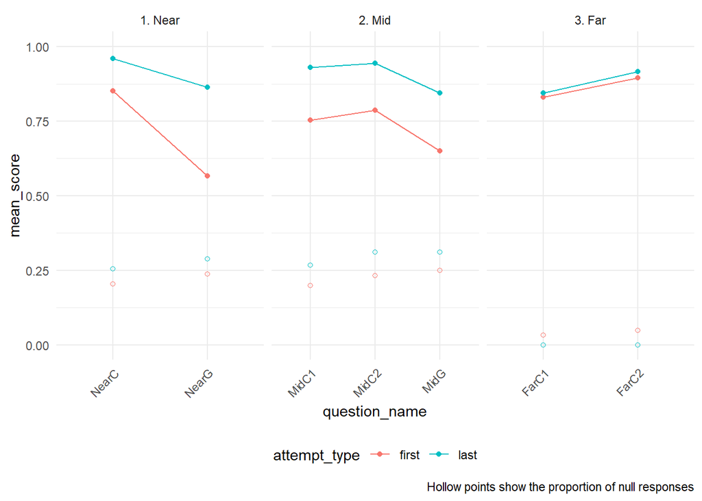

```r
attempts_summary_stats %>%
  ggplot(aes(x = question_name,
             y = mean_score,
             colour = attempt_type,
             group = attempt_type)) +
  geom_point() +
  geom_line() +
  geom_point(data = attempts_summary_stats,
             mapping = aes(x = question_name,
                 y = null_response),
             shape = 1) +
  facet_wrap(~plot_order, scales = "free_x") +
  theme_minimal() +
  theme(axis.text.x = element_text(angle = 45, hjust = 1),
        legend.position = "bottom") +
  ylim(c(0,1)) +
  labs(caption = "Hollow points show the proportion of null responses")
```

# Item details

For each item, we have full details of the student response and how it was graded by STACK. Here is an example for each of the tasks:

```r
responses_raw <- attempt_data_all %>%
  filter(
    str_detect(question_name, "Near|Mid|Far"),
    attempt_number == 1,
    !is.na(marks_attained)
  ) %>%
  select(group, username, question_name, questionsummary, responsesummary, marks_attained)

responses_raw %>% group_by(question_name) %>% slice_head() %>% basic_kable()
```

group

username

question_name

questionsummary

responsesummary

marks_attained

G-CG

anon100

FarC1

${6-4\,n}$ is Decreasing and Bounded above

ans1: “Decreasing” [score]; ans2: “Bounded above” [score]; prt1: ATAlgEquiv_String | prt1-1-T; prt2: ATAlgEquiv_String | prt2-1-T

2

G-CG

anon100

FarC2

${\left[ \frac{1}{2\,n+3} , \mbox{Decreasing} , \mbox{Bounded} \right]}$

ans1: “Decreasing” [score]; ans2: “Unbounded” [score]; prt1: ATAlgEquiv_String | prt1-1-T; prt2: ATAlgEquiv_String | prt2-1-F

1

G-CG

anon100

MidC1

${5-3\,n}$ is Decreasing and Bounded above

ans1: “Decreasing” [score]; ans2: “Unbounded” [score]; prt1: ATAlgEquiv_String | prt1-1-T; prt2: ATAlgEquiv_String | prt2-1-F

1

G-CG

anon100

MidC2

${\left(-2\right)^{n+1}}$ is Neither increasing nor decreasing and Unbounded

ans1: “Decreasing” [score]; ans2: “Bounded below” [score]; prt1: ATAlgEquiv_String | prt1-1-F; prt2: ATAlgEquiv_String | prt2-1-F

0

G-CG

anon100

MidG

In each case below, give an example of an arithmetic sequence with the stated property, by entering an expression for the general term. If it is not possible, enter none.

1. Increasing

Â Â Â $u_n=$ [[input:ans1]][[feedback:prt1]] [[validation:ans1]]

2. Decreasing

Â Â Â $u_n=$ [[input:ans2]][[feedback:prt2]] [[validation:ans2]]

3. Bounded above

Â Â Â $u_n=$ [[input:ans3]][[feedback:prt3]] [[validation:ans3]]

(D)Â Decreasing and bounded below

Â Â Â $u_n=$ [[input:ans4]][[feedback:prt4]] [[validation:ans4]]

ans1: 6+3*n [score]; ans2: 5-4*n [score]; ans3: 7-5*n [score]; ans4: none [score]; prt1: ATAlgEquiv_SA_not_logic. | prt1-3-F | ATLogic_True | prt1-1-T | ATGT_true. | prt1-2-T; prt2: ATAlgEquiv_SA_not_logic. | prt2-3-F | ATLogic_True | prt2-1-T | ATGT_true. | prt2-2-T; prt3: ATAlgEquiv_SA_not_logic. | prt3-3-F | ATLogic_True | prt3-1-T | ATGTE_true. | prt3-2-T; prt4: ATEquation_empty | prt4-1-T

4

G-CG

anon100

NearC

${\left[ \frac{1}{4\,n+4} , \mbox{Decreasing} , \mbox{Bounded} \right]}$

ans1: “Decreasing” [score]; ans2: “Bounded” [score]; prt1: ATAlgEquiv_String | prt1-1-T; prt2: ATAlgEquiv_String | prt2-1-T

2

G-CG

anon100

NearG

Give an example of a sequence which is increasing and bounded above.

(Give your answer as a formula for the $n$th term.)

$u_n=$ [[input:ans1]] [[validation:ans1]]

ans1: 1-1/2^n [score]; prt1: ATLogic_True | prt1-1-T | prt1-3-F | ATLogic_True | prt1-4-T

1

We process this raw data to extract the answers to each part, and the score.

```r
responses <- responses_raw %>%
  # pick out the various answers - str_match_all returns a matrix, which we have to wrangle a bit
  mutate(ans_bits = str_match_all(responsesummary, "(ans[^:]*): ([^;]*)(?=\\[score\\];)")) %>%
  #mutate(ans_bits = str_match_all(responsesummary, "(ans[:digit:]): ([^;]*)(?=\\[score\\];)")) %>%
  mutate(ans_bits = map(ans_bits, ~ tibble(part = .x[,2], response = .x[,3]))) %>%
  unnest(ans_bits) %>%
  mutate(response = str_remove_all(response, '"')) %>%
  # construct a simplified name for each question part
  mutate(q_part = paste(question_name, part, sep = "_")) %>%
  mutate(
    relevant_prt = case_when(
      # pick out the PRT trace that is relevant to each part, i.e. that grades that answer
      # for these questions, ansN corresponds to prtN in all cases
      TRUE ~ str_match_all(responsesummary, str_glue("prt{parse_number(part)}: [^;]*(?=; |$)")) %>% as.character()
    ),
    fully_correct = case_when(
      # the classification tasks all have very simple PRTs with a single node deciding the mark
      str_detect(question_name, "C") ~ str_detect(relevant_prt, "-1-T"),
      # MidG also has quite simple PRTs
      q_part %in% c("MidG_ans1", "MidG_ans2", "MidG_ans3") ~ str_detect(relevant_prt, "-2-T"),
      q_part == "MidG_ans4" ~ str_detect(relevant_prt, "-1-T"),
      # NearG should be increasing (-1-T) and bounded (-4-T)
      question_name == "NearG" ~ str_detect(relevant_prt, "-1-T") & str_detect(relevant_prt, "-4-T"),
      TRUE ~ NA
    )
  )
```

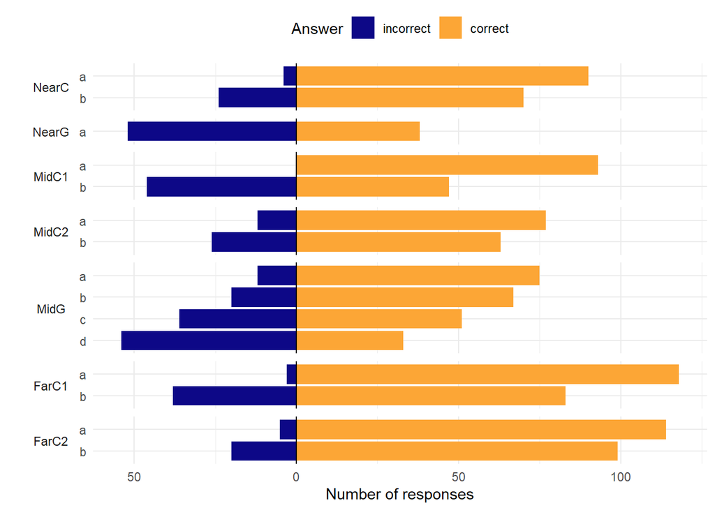

```r
# responses %>%
#   group_by(question_name, part) %>%
#   summarise(
#     n = n(),
#     num_correct = sum(fully_correct),
#     num_incorrect = sum(!fully_correct),
#     prop_correct = num_correct / n,
#     .groups = "drop"
#   ) %>%
#   pivot_longer(cols = starts_with("num_"), names_to = "type", values_to = "count", names_prefix = "num_") %>%
#   mutate(signed_count = if_else(type == "correct", count, -count)) %>%
#   mutate(question_name = fct_relevel(question_name, "NearC", "NearG", "MidC1", "MidC2", "MidG", "FarC1", "FarC2")) %>%
#   mutate(section = str_extract(question_name, "Near|Mid|Far") %>% fct_relevel("Near", "Mid", "Far")) %>%
#   mutate(q_part = fct_rev(paste0(str_extract(question_name, "G|C[:digit:]?"), letters[parse_number(part)]))) %>%
#   mutate(part = fct_rev(letters[parse_number(part)])) %>%
#   ggplot(aes(x = q_part, y = signed_count, fill = type)) +
#   geom_bar(position = "stack", stat = "identity") +
#   geom_hline(yintercept = 0) +
#   coord_flip() +
#   scale_y_continuous("Number of responses", labels = abs, breaks = seq(-50, 100, 50)) +
#   scale_fill_viridis_d("Answer", option = "plasma", end = 0.8, direction = -1, guide = guide_legend(reverse = TRUE)) +
#   facet_grid(rows = vars(section), scales = "free", space = "free", switch = "both") +
#   theme(
#     strip.placement = "outside",
#     strip.text.y.left = element_text(angle = 0),
#     legend.position = "top"
#   ) +
#   labs(x = "")

responses %>%
  group_by(question_name, part) %>%
  summarise(
    n = n(),
    num_correct = sum(fully_correct),
    num_incorrect = sum(!fully_correct),
    prop_correct = num_correct / n,
    .groups = "drop"
  ) %>%
  pivot_longer(cols = starts_with("num_"), names_to = "type", values_to = "count", names_prefix = "num_") %>%
  mutate(signed_count = if_else(type == "correct", count, -count)) %>%
  mutate(question_name = fct_relevel(question_name, "NearC", "NearG", "MidC1", "MidC2", "MidG", "FarC1", "FarC2")) %>%
  mutate(part = fct_rev(letters[parse_number(part)])) %>%
  ggplot(aes(x = part, y = signed_count, fill = type)) +
  geom_bar(position = "stack", stat = "identity") +
  geom_hline(yintercept = 0) +
  coord_flip() +
  scale_y_continuous("Number of responses", labels = abs, breaks = seq(-50, 100, 50)) +
  scale_fill_viridis_d("Answer", option = "plasma", end = 0.8, direction = -1, guide = guide_legend(reverse = TRUE)) +
  facet_grid(rows = vars(question_name), scales = "free", space = "free", switch = "both") +
  theme(
    strip.placement = "outside",
    strip.text.y.left = element_text(angle = 0),
    legend.position = "top"
  ) +
  labs(x = "")
```

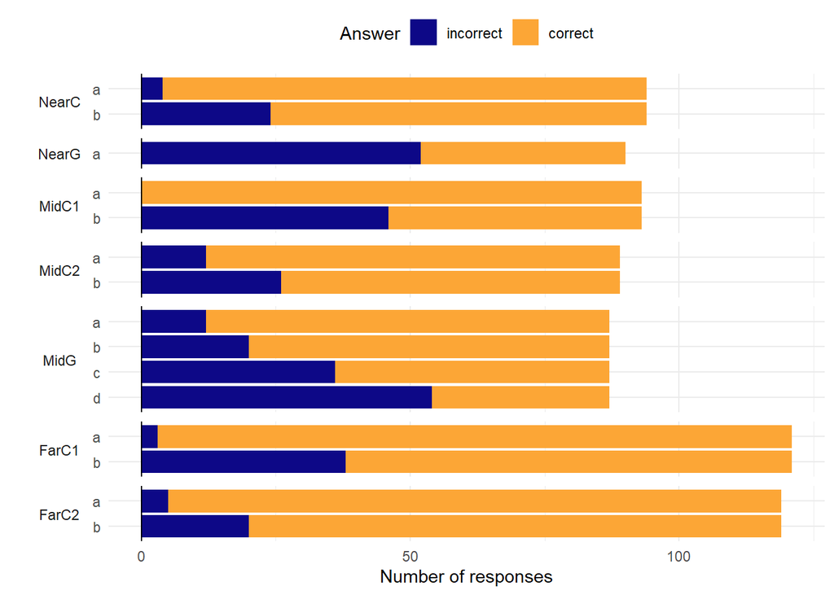

```r
responses %>%
  group_by(question_name, part) %>%
  summarise(
    n = n(),
    num_correct = sum(fully_correct),
    num_incorrect = sum(!fully_correct),
    prop_correct = num_correct / n,
    .groups = "drop"
  ) %>%
  pivot_longer(cols = starts_with("num_"), names_to = "type", values_to = "count", names_prefix = "num_") %>%
  mutate(signed_count = if_else(type == "correct", count, -count)) %>%
  mutate(question_name = fct_relevel(question_name, "NearC", "NearG", "MidC1", "MidC2", "MidG", "FarC1", "FarC2")) %>%
  mutate(part = fct_rev(letters[parse_number(part)])) %>%
  ggplot(aes(x = part, y = count, fill = type)) +
  geom_bar(position = "stack", stat = "identity") +
  geom_hline(yintercept = 0) +
  coord_flip() +
  scale_y_continuous("Number of responses", labels = abs, breaks = seq(-50, 100, 50)) +
  scale_fill_viridis_d("Answer", option = "plasma", end = 0.8, direction = -1, guide = guide_legend(reverse = TRUE)) +
  facet_grid(rows = vars(question_name), scales = "free", space = "free", switch = "both") +
  theme(
    strip.placement = "outside",
    strip.text.y.left = element_text(angle = 0),
    legend.position = "top"
  ) +
  labs(x = "")
```

```r
ggsave("figs/FIG_study1_subsequent-task-scores.eps", device = cairo_ps, width = 12, height = 9, units = "cm")
```

```r
task_order_data <- responses %>%
  filter(str_detect(question_name, "Near|Mid")) %>%
  mutate(q_type = if_else(str_detect(question_name, "C"), "C", "G")) %>%
  select(group, username, question_name, q_type, marks_attained) %>%
  distinct() %>%
  group_by(group, username, q_type) %>%
  tally(marks_attained, name = "marks_attained") %>%
  pivot_wider(names_from = "q_type", values_from = "marks_attained", values_fill = 0) %>%
  mutate(task_order = if_else(str_detect(group, "CG"), "Classify first", "Generate first"))
```

There are several students who did not complete any of the relevant tasks, and they seem to be disproportionately from the “Classify first” group which would skew the results:

```r
participants %>%
  anti_join(task_order_data %>% select(username) %>% distinct(), by = "username") %>%
  # tidy up group names
  mutate(
    group = str_replace(group, "LGE Group ", ""),
    group = str_glue("{str_sub(group, 1, 1)}-{str_sub(group, 2, 3)}")
  ) %>%
  mutate(task_order = if_else(str_detect(group, "CG"), "Classify first", "Generate first")) %>%
  janitor::tabyl(task_order) %>%
  basic_kable(caption = "Students who did not answer any of the Near or Mid tasks")
```

Students who did not answer any of the Near or Mid tasks

| task_order | n | percent |
| --- | --- | --- |
| Classify first | 28 | 0.6829268 |
| Generate first | 13 | 0.3170732 |

So we stick with just the 102 students who completed at least one of the Near/Mid tasks.

```r
task_order_model_C <- stan_glm(
    formula = C ~ 0 + task_order,
    data = task_order_data,
    seed = 123,
    refresh = 0 # to prevent messages about the MCMC iterations being printed
  )
means_C <- modelbased::estimate_means(task_order_model_C, ci = ci_width, centrality = "median", ci_method = "hdi")
```

```
## We selected `at = c("task_order")`.
```

```r
contrasts_C <- modelbased::estimate_contrasts(task_order_model_C, ci = ci_width, centrality = "median", ci_method = "hdi")
```

```
## No variable was specified for contrast estimation. Selecting `contrast = "task_order"`.
```

```r
task_order_model_G <- stan_glm(
    formula = G ~ 0 + task_order,
    data = task_order_data,
    seed = 123,
    refresh = 0 # to prevent messages about the MCMC iterations being printed
  )
means_G <- modelbased::estimate_means(task_order_model_G, ci = ci_width, centrality = "median", ci_method = "hdi")
```

```
## We selected `at = c("task_order")`.
```

```r
contrasts_G <- modelbased::estimate_contrasts(task_order_model_G, ci = ci_width, centrality = "median", ci_method = "hdi")
```

```
## No variable was specified for contrast estimation. Selecting `contrast = "task_order"`.
```

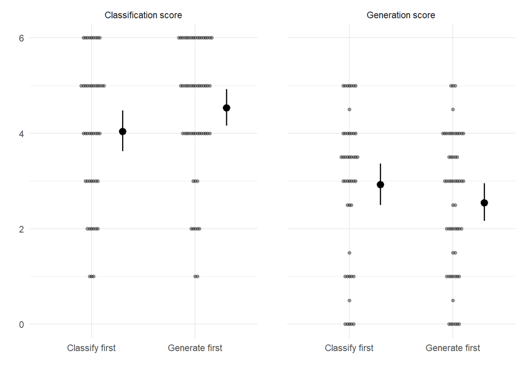

```r
means = bind_rows("C" = means_C, "G" = means_G, .id = "q_type")
contrasts = bind_rows("C" = contrasts_C, "G" = contrasts_G, .id = "q_type")

task_order_data %>%
  pivot_longer(cols = c("G", "C"), names_to = "q_type", values_to = "marks_attained") %>%
  ggplot(aes(x = task_order, y = marks_attained)) +
  ggbeeswarm::geom_beeswarm(alpha = 0.4, stroke = 0) +
  geom_pointrange(data = means, aes(x = task_order, y = Mean, ymin = CI_low, ymax = CI_high),
                  position = position_nudge(x = 0.3),
                  size = 0.6) +
  facet_grid(cols = vars(q_type), labeller = labeller(q_type = c("C" = "Classification score", "G" = "Generation score"))) +
  labs(y = "", x = "") +
  theme(panel.spacing.x = unit(2, "lines"))
```

```r
ggsave("figs/FIG_study1_task_order.eps", device = cairo_ps, width = 12, height = 7, units = "cm")
```

```r
task_order_means_table <- means %>%
  left_join(
    task_order_data %>%
      pivot_longer(cols = c("G", "C"), names_to = "q_type", values_to = "marks_attained") %>%
      group_by(q_type, task_order) %>%
      summarise(
        N = n(),
        sd = sd(marks_attained),
        .groups = "drop"
      ),
    by = c("q_type", "task_order")
  ) %>%
  relocate(N, .before = Mean) %>%
  mutate(score = if_else(q_type == "C", "Classification", "Generation"), .before = 1, .keep = "unused") %>%
  mutate(estimate_hdi = str_glue("[{round(CI_low, 3)}, {round(CI_high, 3)}]"), .keep = "unused")

task_order_means_table %>%
  basic_kable(digits = 3) %>%
  collapse_rows(columns = 1, valign = "top")
```

| score | task_order | N | Mean | sd | estimate_hdi |
| --- | --- | --- | --- | --- | --- |
| Classification | Classify first | 46 | 4.039 | 1.534 | [3.626, 4.479] |
| Classification | Generate first | 56 | 4.535 | 1.401 | [4.158, 4.922] |
| Generation | Classify first | 46 | 2.923 | 1.588 | [2.5, 3.363] |
| Generation | Generate first | 56 | 2.544 | 1.453 | [2.164, 2.953] |

```r
task_order_means_table %>%
  basic_kable(digits = 3, format = "latex", booktabs = T) %>%
  cat()
```

```
\begin{table}
\centering
\begin{tabular}{llrrrl}
\toprule
score & task\_order & N & Mean & sd & estimate\_hdi\\
\midrule
Classification & Classify first & 46 & 4.039 & 1.534 & {}[3.626, 4.479]\\
Classification & Generate first & 56 & 4.535 & 1.401 & {}[4.158, 4.922]\\
Generation & Classify first & 46 & 2.923 & 1.588 & {}[2.5, 3.363]\\
Generation & Generate first & 56 & 2.544 & 1.453 & {}[2.164, 2.953]\\
\bottomrule
\end{tabular}
\end{table}
```

```r
contrasts %>%
  basic_kable(digits = 3)
```

| q_type | Level1 | Level2 | Difference | CI_low | CI_high | pd | ROPE_Percentage |
| --- | --- | --- | --- | --- | --- | --- | --- |
| C | Classify first | Generate first | -0.500 | -1.048 | 0.079 | 0.960 | 0.059 |
| G | Classify first | Generate first | 0.375 | -0.178 | 0.974 | 0.894 | 0.138 |

# Near tasks

## NearG

```r
responses %>%
  filter(question_name == "NearG") %>%
  write_csv("data-clean/study1_NearG_responses.csv")

responses %>%
  filter(question_name == "NearG") %>%
  group_by(fully_correct, relevant_prt, response) %>%
  tally() %>%
  arrange(relevant_prt, -n)
```

| fully_correct | relevant_prt | response | n |
| --- | --- | --- | --- |
| FALSE | prt1: ATAlgEquiv_SA_not_logic. \| prt1-1-F \| ATAlgEquiv_SA_not_logic. \| prt1-2-F | sin(n) | 1 |
| FALSE | prt1: ATAlgEquiv_SA_not_logic. \| prt1-1-F \| ATAlgEquiv_SA_not_logic. \| prt1-2-F | sqrt(10-n) | 1 |
| TRUE | prt1: ATLogic_True \| prt1-1-T \| prt1-3-F \| ATLogic_True \| prt1-4-T | 1-1/2^n | 9 |
| TRUE | prt1: ATLogic_True \| prt1-1-T \| prt1-3-F \| ATLogic_True \| prt1-4-T | -1/n | 5 |
| TRUE | prt1: ATLogic_True \| prt1-1-T \| prt1-3-F \| ATLogic_True \| prt1-4-T | 1-1/n | 5 |
| TRUE | prt1: ATLogic_True \| prt1-1-T \| prt1-3-F \| ATLogic_True \| prt1-4-T | 1-(1/2)^n | 3 |
| TRUE | prt1: ATLogic_True \| prt1-1-T \| prt1-3-F \| ATLogic_True \| prt1-4-T | 5-1/n | 2 |
| TRUE | prt1: ATLogic_True \| prt1-1-T \| prt1-3-F \| ATLogic_True \| prt1-4-T | -1-1/2^n | 1 |
| TRUE | prt1: ATLogic_True \| prt1-1-T \| prt1-3-F \| ATLogic_True \| prt1-4-T | -1/(4*n) | 1 |
| TRUE | prt1: ATLogic_True \| prt1-1-T \| prt1-3-F \| ATLogic_True \| prt1-4-T | -3/n | 1 |

[output cut: 50 more lines]

```r
responses %>%
  filter(question_name == "NearG") %>%
  separate(group, into = c("initial_task", "task_order"), sep = "-", remove = FALSE) %>%
  group_by(initial_task, task_order, fully_correct, relevant_prt) %>%
  arrange(response) %>%
  summarise(
    responses = paste0(str_trim(response), collapse = "; "),
    .groups = "drop"
  ) %>%
  basic_kable() %>%
  collapse_rows(columns = c(1:3), valign = "top")
```

| initial_task | task_order | fully_correct | relevant_prt | responses |
| --- | --- | --- | --- | --- |
| C | CG | FALSE | prt1: ATAlgEquiv_SA_not_logic. \| prt1-1-F \| ATAlgEquiv_SA_not_logic. \| prt1-2-F | sin(n); sqrt(10-n) |
| C | CG | FALSE | prt1: ATLogic_True \| prt1-1-T \| prt1-3-F \| prt1-4-F | 1/2*n; 1/2*n+1; 1+2*n; 2*n -1; 2^n; 5/2*n; sqrt(n) |
| C | CG | FALSE | prt1: prt1-1-F \| ATLogic_True \| prt1-2-T | 1; 1/(2*n+4); 1+u_n |
| C | CG | TRUE | prt1: ATLogic_True \| prt1-1-T \| prt1-3-F \| ATLogic_True \| prt1-4-T | -1/(4*n); -1/n; -3/n; 1-(1/2)^n; 1-1/n; 1/-n |
| C | GC | FALSE | prt1: ATLogic_True \| prt1-1-T \| prt1-3-F \| prt1-4-F | 1/4*n+1; 6^n; ln(n); n/2; n^2-1; n^2; n^2 |
| C | GC | FALSE | prt1: prt1-1-F \| ATLogic_True \| prt1-2-T | (2*n+3)/(n+1); 0; 1/(4*n+4); 1/n; 1^-n; 1^n; 7; log(x); u_n/5 |
| C | GC | TRUE | prt1: ATLogic_True \| prt1-1-T \| prt1-3-F \| ATLogic_True \| prt1-4-T | -1/n; (n-1)/n; 10-1/n; 2-1/(2*n); 4-1/(4*n); 5-(1/2^n); 5-1/2^n; 5-1/n |
| G | CG | FALSE | prt1: ATLogic_True \| prt1-1-T \| prt1-3-F \| prt1-4-F | 1+n; 1+n; 2*n+4; 2^n; 2^n; 3*n+1; 3*n+2; ln(n) |
| G | CG | FALSE | prt1: prt1-1-F \| ATLogic_True \| prt1-2-T | 1; 1/2^n; 1/2^n; 1/3**n; 1/n; 1/n+9 |
| G | CG | TRUE | prt1: ATLogic_True \| prt1-1-T \| prt1-3-F \| ATLogic_True \| prt1-4-T | -1-1/2^n; -1/n; 1-1/2^n; 1-1/2^n; 1-1/2^n; 1-1/2^n; 1-1/2^n; 1-1/n; 2-2/n; 257/16-1/2^n |
| G | GC | FALSE | prt1: ATLogic_True \| prt1-1-T \| prt1-3-F \| prt1-4-F | 4^n+1; ln(n); ln(n); n -1/2^n |
| G | GC | FALSE | prt1: prt1-1-F \| ATLogic_True \| prt1-2-T | 0; 1+1/2^n; 2+1/n; 4; n-n^2; x |
| G | GC | TRUE | prt1: ATLogic_True \| prt1-1-T \| prt1-3-F \| ATLogic_True \| prt1-4-T | -1/n; -1/n; 1-(1/2)^n; 1-(1/2)^n; 1-1/2^n; 1-1/2^n; 1-1/2^n; 1-1/2^n; 1-1/n; 1-1/n; 1-1/n; 5-1/n; n/(n+1); u_1-1/n |

# Mid tasks

## MidG

```r
responses %>%
  filter(question_name == "MidG") %>%
  write_csv("data-clean/study1_MidG_responses.csv")

responses %>%
  filter(question_name == "MidG") %>%
  group_by(q_part, fully_correct, response) %>%
  tally() %>%
  arrange(q_part, fully_correct, -n)
```

| q_part | fully_correct | response | n |
| --- | --- | --- | --- |
| MidG_ans1 | FALSE | 1 | 3 |
| MidG_ans1 | FALSE | [1,3,5,7] | 1 |
| MidG_ans1 | FALSE | [2,4,6,8] | 1 |
| MidG_ans1 | FALSE | 111 | 1 |
| MidG_ans1 | FALSE | 2u_n+1 | 1 |
| MidG_ans1 | FALSE | 3 | 1 |
| MidG_ans1 | FALSE | 9 | 1 |
| MidG_ans1 | FALSE | a+3*(n-1) | 1 |
| MidG_ans1 | FALSE | n*d | 1 |
| MidG_ans1 | FALSE | u_1 | 1 |

[output cut: 208 more lines]

```r
responses %>%
  filter(question_name == "MidG", q_part == "MidG_ans3") %>%
  separate(group, into = c("initial_task", "task_order"), sep = "-", remove = FALSE) %>%
  group_by(initial_task, task_order, fully_correct, relevant_prt) %>%
  arrange(response) %>%
  summarise(
    responses = paste0(str_trim(response), collapse = "; "),
    .groups = "drop"
  ) %>%
  basic_kable() %>%
  collapse_rows(columns = c(1:3), valign = "top")
```

| initial_task | task_order | fully_correct | relevant_prt | responses |
| --- | --- | --- | --- | --- |
| C | CG | FALSE | prt3: # = 0 \| ATAlgEquiv_SA_not_logic. \| prt3-3-F \| prt3-1-F | 1-1/(3*n); 1/n |
| C | CG | FALSE | prt3: ATAlgEquiv_SA_not_logic. \| prt3-3-F \| ATLogic_True \| prt3-1-T \| ATGTE_false. \| prt3-2-F | 4*n +5 |
| C | CG | FALSE | prt3: ATAlgEquiv_SA_not_logic. \| prt3-3-F \| prt3-1-F | 1-2u_n; 1-n*d |
| C | CG | TRUE | prt3: ATAlgEquiv_SA_not_logic. \| prt3-3-F \| ATLogic_True \| prt3-1-T \| ATGTE_true. \| prt3-2-T | -2*n-2; -2*n; -3*n-1; -n; 1-2*n; 1-n; 100-n; 2 - n; 3-2*n; 5-3*n; 5-5*(n-1); 5-7n; 9-5*n |
| C | GC | FALSE | prt3: # = 0 \| ATAlgEquiv_SA_not_logic. \| prt3-3-F \| prt3-1-F | 1-1/n; 1-1/n; 1-1/n; 1/n |
| C | GC | FALSE | prt3: ATAlgEquiv_SA_not_logic. \| prt3-3-F \| ATLogic_True \| prt3-1-T \| ATGTE_false. \| prt3-2-F | 1+(n-1)*2; 1+n; 3+5(n-1) |
| C | GC | FALSE | prt3: ATAlgEquiv_SA_not_logic. \| prt3-3-F \| prt3-1-F | (-1)^n; 1+1/(n^2+1) |
| C | GC | FALSE | prt3: ATEquation_empty \| prt3-3-T | none; none; none; none; none; none |
| C | GC | TRUE | prt3: ATAlgEquiv_SA_not_logic. \| prt3-3-F \| ATLogic_True \| prt3-1-T \| ATGTE_true. \| prt3-2-T | -2*(n-1); -n; 0; 0; 1-(n-1)5; 2-2(n-1); 2; 5-1/5*(n-1); 9 |
| G | CG | FALSE | prt3: ATAlgEquiv_SA_not_logic. \| prt3-3-F \| ATLogic_True \| prt3-1-T \| ATGTE_false. \| prt3-2-F | 5 + 2*(n-1) |
| G | CG | FALSE | prt3: ATAlgEquiv_SA_not_logic. \| prt3-3-F \| prt3-1-F | 1+1/2^n |
| G | CG | FALSE | prt3: ATEquation_empty \| prt3-3-T | none |
| G | CG | TRUE | prt3: ATAlgEquiv_SA_not_logic. \| prt3-3-F \| ATLogic_True \| prt3-1-T \| ATGTE_true. \| prt3-2-T | -n; -n; 1-n; 1-n; 1; 1; 1; 100-n; 2-n; 34892-n; 5-2*n; 5-3*n; 5-n; 6-2*n; 7-4*n; 7-5*n; 7-5*n; 9-n |
| G | GC | FALSE | prt3: # = 0 \| ATAlgEquiv_SA_not_logic. \| prt3-3-F \| prt3-1-F | -1/n; 1-2(1/n); 2-1/(2n); 2-1/n |
| G | GC | FALSE | prt3: ATAlgEquiv_SA_not_logic. \| prt3-3-F \| ATLogic_True \| prt3-1-T \| ATGTE_false. \| prt3-2-F | 4/3*n |
| G | GC | FALSE | prt3: ATAlgEquiv_SA_not_logic. \| prt3-3-F \| prt3-1-F | 1-1/(2^n) |
| G | GC | FALSE | prt3: ATEquation_empty \| prt3-3-T | none; none; none; none; none; none; none |
| G | GC | TRUE | prt3: ATAlgEquiv_SA_not_logic. \| prt3-3-F \| ATLogic_True \| prt3-1-T \| ATGTE_true. \| prt3-2-T | 1; 1; 1 - (1/2)*(n-1); 1 - (n-1)*3; 1+(n-1)*(-2); 2-((1/2)*(n-1)); 2-2(n-1); 2-5(n-1); 2; 3-2*n; 4-1*(n-1) |

Further analysis of this is postponed to `studyX_task-interactions` which combines this data with further data from Study 2.